# jamboree

## 🔹ABOUT:

- Jamboree is a renowned educational institution that has successfully assisted numerous students in gaining admission to top colleges abroad. With their proven problem-solving methods, they have helped students achieve exceptional scores on exams like GMAT, GRE, and SAT with minimal effort.
- To further support students, Jamboree has recently introduced a new feature on their website. This feature enables students to assess their probability of admission to Ivy League colleges, considering the unique perspective of Indian applicants.
- By conducting a thorough analysis, we can assist Jamboree in understanding the crucial factors impacting graduate admissions and their interrelationships. Additionally, we can provide predictive insights to determine an individual's admission chances based on various variables.

## 🔹Why this Case study?

- Solving this business case holds immense importance for aspiring data scientists and ML engineers.
- Building predictive models using machine learning is widely popular among the data scientists/ML engineers. By working through this case study, individuals gain hands-on experience and practical skills in the field.
- Additionally, it will enhance one's ability to communicate with the stakeholders involved in data-related projects and help the organization take better, data-driven decisions.

### 🤞Work that has to be done:

> As a data scientist/ML engineer hired by Jamboree, your primary objective is toanalyze the given dataset and derive valuable insights from it. Additionally, utilize the dataset to construct a predictive model capable of estimating an applicant's likelihood of admission based on the available features.

### 📃 Features of the dataset:

> Column Profiling:

| Feature | Description |
| --- | --- |
| Serial No. | This column represents the unique row identifier for each applicant in the dataset. |
| GRE Scores | This column contains the GRE (Graduate Record Examination) scores of the applicants, which are measured on a scale of 0 to 340. |
| TOEFL Scores | This column includes the TOEFL (Test of English as a Foreign Language) scores of the applicants, which are measured on a scale of 0 to 120. |
| University Rating | This column indicates the rating or reputation of the university that the applicants are associated with , & The rating is based on a scale of 0 to 5, with 5 representing the highest rating. |
| SOP | This column represents the strength of the applicant's statement of purpose, rated on a scale of 0 to 5, with 5 indicating a strong and compelling SOP. |
| LOR | This column represents the strength of the applicant's letter of recommendation, rated on a scale of 0 to 5, with 5 indicating a strong and compelling LOR. |
| CGPA | This column contains the undergraduate Grade Point Average (GPA) of the applicants, which is measured on a scale of 0 to 10. |
| Research | This column indicates whether the applicant has research experience (1) or not (0). |
| Chance of Admit | This column represents the estimated probability or chance of admission for each applicant, ranging from 0 to 1. |

These columns provide relevant information about the applicants' academic qualifications, testscores, university ratings, and other factors that may influence their chances of admission.

```python
import pandas as pd
import numpy as np
import matplotlib.pyplot as plt
%matplotlib inline
import seaborn as sns

from sklearn.preprocessing import StandardScaler , MinMaxScaler , PolynomialFeatures
from sklearn.pipeline import make_pipeline
from sklearn.model_selection import train_test_split
from sklearn.linear_model import LinearRegression, Ridge, Lasso, ElasticNet
from sklearn.metrics import r2_score, mean_absolute_error, mean_squared_error
from sklearn.feature_selection import RFE

from scipy import stats
from statsmodels.stats.outliers_influence import variance_inflation_factor

import statsmodels.api as sm
import statsmodels.stats.api as sms

import warnings
warnings.filterwarnings('ignore')
```

```python
jm_data = pd.read_csv('Jamboree_Admission.csv')
df = jm_data.copy()
df.tail()
```

|  | Serial No. | GRE Score | TOEFL Score | University Rating | SOP | LOR | CGPA | Research | Chance of Admit |
| --- | --- | --- | --- | --- | --- | --- | --- | --- | --- |
| 495 | 496 | 332 | 108 | 5 | 4.5 | 4.0 | 9.02 | 1 | 0.87 |
| 496 | 497 | 337 | 117 | 5 | 5.0 | 5.0 | 9.87 | 1 | 0.96 |
| 497 | 498 | 330 | 120 | 5 | 4.5 | 5.0 | 9.56 | 1 | 0.93 |
| 498 | 499 | 312 | 103 | 4 | 4.0 | 5.0 | 8.43 | 0 | 0.73 |
| 499 | 500 | 327 | 113 | 4 | 4.5 | 4.5 | 9.04 | 0 | 0.84 |

### 🧐**Exploration of data :**

```python
df = df.rename(columns={'Chance of Admit ': 'Chance_of_Admit'})
```

```python
df.shape
```

```
(500, 9)
```

```python
df.info()
```

```
<class 'pandas.core.frame.DataFrame'>
RangeIndex: 500 entries, 0 to 499
Data columns (total 9 columns):
 #   Column             Non-Null Count  Dtype
---  ------             --------------  -----
 0   Serial No.         500 non-null    int64
 1   GRE Score          500 non-null    int64
 2   TOEFL Score        500 non-null    int64
 3   University Rating  500 non-null    int64
 4   SOP                500 non-null    float64
 5   LOR                500 non-null    float64
 6   CGPA               500 non-null    float64
 7   Research           500 non-null    int64
 8   Chance_of_Admit    500 non-null    float64
dtypes: float64(4), int64(5)
memory usage: 35.3 KB
```

### 📝 Statistical Summary

```python
df.cov()
```

|  | Serial No. | GRE Score | TOEFL Score | University Rating | SOP | LOR | CGPA | Research | Chance_of_Admit |
| --- | --- | --- | --- | --- | --- | --- | --- | --- | --- |
| Serial No. | 20875.000000 | -169.458918 | -124.511022 | -11.175351 | -19.666333 | -0.493988 | -6.491703 | -0.382766 | 0.173437 |
| GRE Score | -169.458918 | 127.580377 | 56.825026 | 8.206605 | 6.867206 | 5.484521 | 5.641944 | 3.162004 | 1.291862 |
| TOEFL Score | -124.511022 | 56.825026 | 36.989114 | 4.519150 | 3.883960 | 3.048168 | 2.981607 | 1.411303 | 0.680046 |
| University Rating | -11.175351 | 8.206605 | 4.519150 | 1.307619 | 0.825014 | 0.644112 | 0.487761 | 0.242645 | 0.111384 |
| SOP | -19.666333 | 6.867206 | 3.883960 | 0.825014 | 0.982088 | 0.608701 | 0.426845 | 0.200962 | 0.095691 |
| LOR | -0.493988 | 5.484521 | 3.048168 | 0.644112 | 0.608701 | 0.856457 | 0.356807 | 0.171303 | 0.084296 |
| CGPA | -6.491703 | 5.641944 | 2.981607 | 0.487761 | 0.426845 | 0.356807 | 0.365799 | 0.150655 | 0.075326 |
| Research | -0.382766 | 3.162004 | 1.411303 | 0.242645 | 0.200962 | 0.171303 | 0.150655 | 0.246894 | 0.038282 |
| Chance_of_Admit | 0.173437 | 1.291862 | 0.680046 | 0.111384 | 0.095691 | 0.084296 | 0.075326 | 0.038282 | 0.019921 |

```python
df.describe().T
```

|  | count | mean | std | min | 25% | 50% | 75% | max |
| --- | --- | --- | --- | --- | --- | --- | --- | --- |
| Serial No. | 500.0 | 250.50000 | 144.481833 | 1.00 | 125.7500 | 250.50 | 375.25 | 500.00 |
| GRE Score | 500.0 | 316.47200 | 11.295148 | 290.00 | 308.0000 | 317.00 | 325.00 | 340.00 |
| TOEFL Score | 500.0 | 107.19200 | 6.081868 | 92.00 | 103.0000 | 107.00 | 112.00 | 120.00 |
| University Rating | 500.0 | 3.11400 | 1.143512 | 1.00 | 2.0000 | 3.00 | 4.00 | 5.00 |
| SOP | 500.0 | 3.37400 | 0.991004 | 1.00 | 2.5000 | 3.50 | 4.00 | 5.00 |
| LOR | 500.0 | 3.48400 | 0.925450 | 1.00 | 3.0000 | 3.50 | 4.00 | 5.00 |
| CGPA | 500.0 | 8.57644 | 0.604813 | 6.80 | 8.1275 | 8.56 | 9.04 | 9.92 |
| Research | 500.0 | 0.56000 | 0.496884 | 0.00 | 0.0000 | 1.00 | 1.00 | 1.00 |
| Chance_of_Admit | 500.0 | 0.72174 | 0.141140 | 0.34 | 0.6300 | 0.72 | 0.82 | 0.97 |

```python
df = df.drop(columns='Serial No.')
df.sample()
```

|  | GRE Score | TOEFL Score | University Rating | SOP | LOR | CGPA | Research | Chance_of_Admit |
| --- | --- | --- | --- | --- | --- | --- | --- | --- |
| 169 | 311 | 99 | 2 | 2.5 | 3.0 | 7.98 | 0 | 0.65 |

```python
df.columns
```

```
Index(['GRE Score', 'TOEFL Score', 'University Rating', 'SOP', 'LOR ', 'CGPA',
       'Research', 'Chance_of_Admit'],
      dtype='object')
```

### 📜📜**Duplicate Detection**

```python
df[df.duplicated()]
```

|  | GRE Score | TOEFL Score | University Rating | SOP | LOR | CGPA | Research | Chance_of_Admit |
| --- | --- | --- | --- | --- | --- | --- | --- | --- |

### 🏷️ Insights

- The dataset does not contain any duplicates.

### 🔸❓**Null Detection**

```python
df.isna().any()
```

```
GRE Score            False
TOEFL Score          False
University Rating    False
SOP                  False
LOR                  False
CGPA                 False
Research             False
Chance_of_Admit      False
dtype: bool
```

```python
df.isna().sum()
```

```
GRE Score            0
TOEFL Score          0
University Rating    0
SOP                  0
LOR                  0
CGPA                 0
Research             0
Chance_of_Admit      0
dtype: int64
```

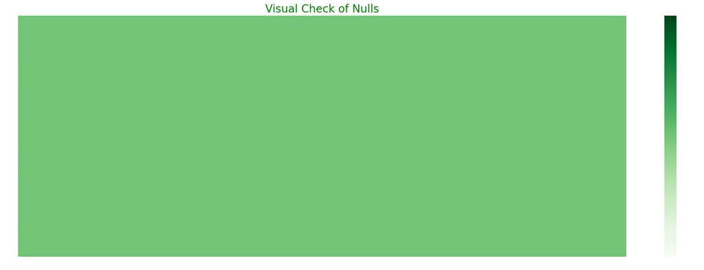

```python
plt.figure(figsize=(25,8))
plt.style.use('dark_background')
sns.heatmap(df.isnull(),cmap='Greens')
plt.title('Visual Check of Nulls',fontsize=20,color='g')
plt.show()
```

```python
for _ in df.columns:
    print()
    print(f'Total Unique Values in {_} column are :- {df[_].nunique()}')
    print(f'Value counts in {_} column are :-\n {df[_].value_counts(normalize=True)}')
    print()
    print('-'*120)
```

```
Total Unique Values in GRE Score column are :- 49
Value counts in GRE Score column are :-
 GRE Score
312    0.048
324    0.046
316    0.036
321    0.034
322    0.034
327    0.034
311    0.032
320    0.032
314    0.032
317    0.030
325    0.030
315    0.026
308    0.026
323    0.026
326    0.024
319    0.024
313    0.024
304    0.024
300    0.024
318    0.024
305    0.022
301    0.022
310    0.022
307    0.020
329    0.020
299    0.020
298    0.020
331    0.018
340    0.018
328    0.018
309    0.018
334    0.016
332    0.016
330    0.016
306    0.014
302    0.014
297    0.012
```

[output cut: 125 more lines]

```
 Chance_of_Admit
0.71    0.046
0.64    0.038
0.73    0.036
0.72    0.032
0.79    0.032
        ...
0.38    0.004
0.36    0.004
0.43    0.002
0.39    0.002
0.37    0.002
Name: proportion, Length: 61, dtype: float64

------------------------------------------------------------------------------------------------------------------------
```

```python
for _ in df.columns:
    print()
    print(f'Range of {_} column is from {df[_].min()} to {df[_].max()}')
    print()
    print('-'*120)
```

```
Range of GRE Score column is from 290 to 340

------------------------------------------------------------------------------------------------------------------------

Range of TOEFL Score column is from 92 to 120

------------------------------------------------------------------------------------------------------------------------

Range of University Rating column is from 1 to 5

------------------------------------------------------------------------------------------------------------------------

Range of SOP column is from 1.0 to 5.0

------------------------------------------------------------------------------------------------------------------------

Range of LOR  column is from 1.0 to 5.0

------------------------------------------------------------------------------------------------------------------------

Range of CGPA column is from 6.8 to 9.92

------------------------------------------------------------------------------------------------------------------------

Range of Research column is from 0 to 1

------------------------------------------------------------------------------------------------------------------------

Range of Chance_of_Admit column is from 0.34 to 0.97

------------------------------------------------------------------------------------------------------------------------
```

```python
#df['Research'] = df.Research.astype('category')
```

```python
df.dtypes
```

```
GRE Score              int64
TOEFL Score            int64
University Rating      int64
SOP                  float64
LOR                  float64
CGPA                 float64
Research               int64
Chance_of_Admit      float64
dtype: object
```

### 📈Graphical Analysis:

```python
cp = 'Greens'
```

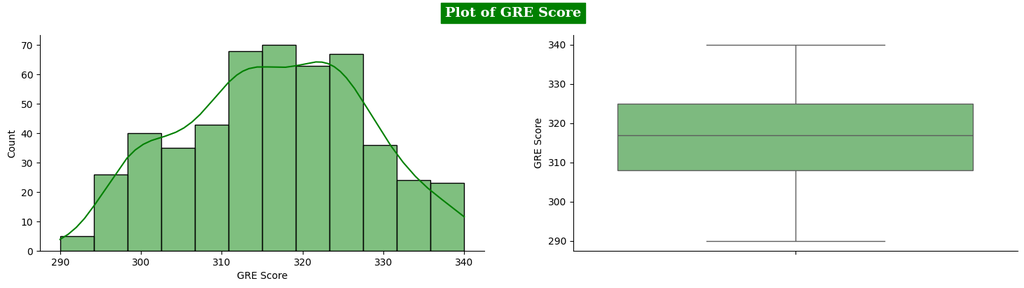

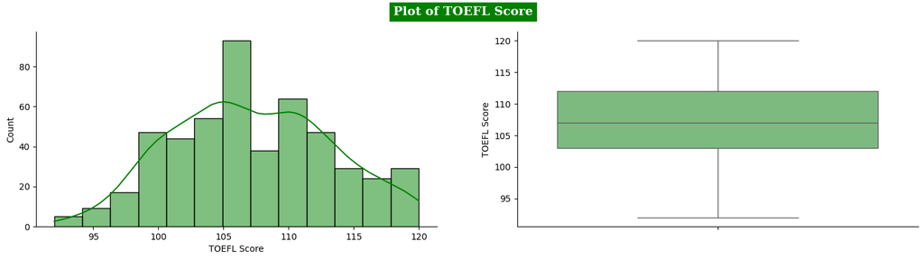

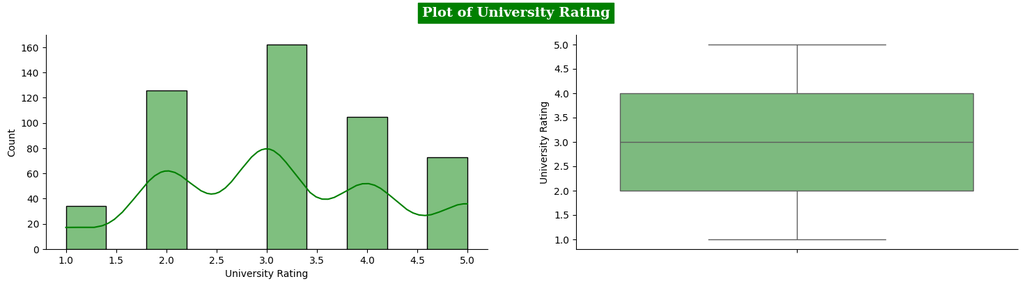

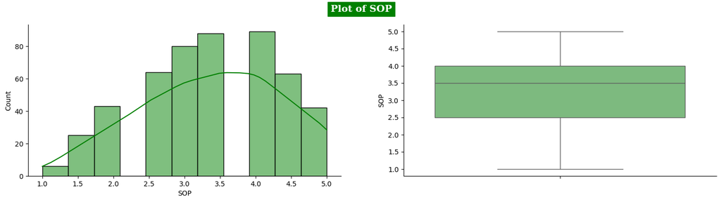

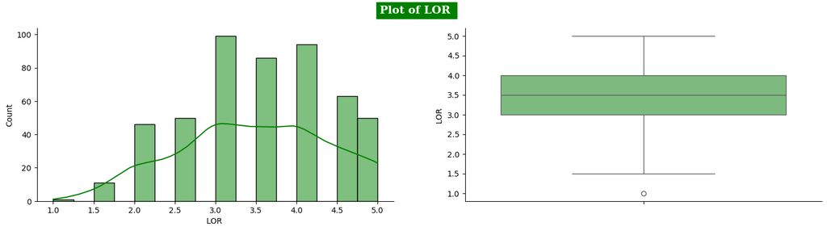

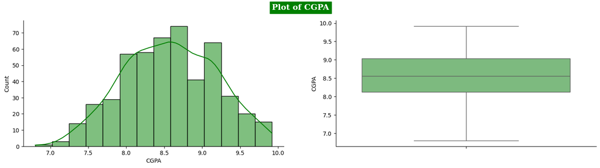

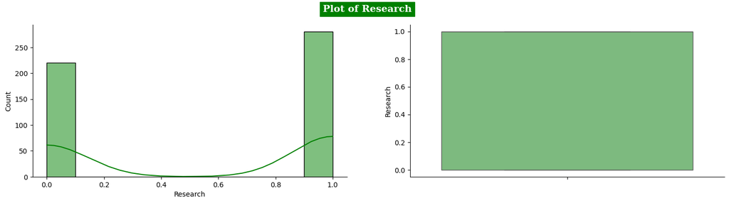

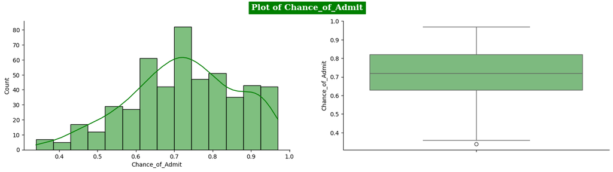

```python
for _ in df.columns:
    plt.style.use('default')
    plt.style.use('fast')
    plt.figure(figsize = (18,4))
    plt.subplot(122)
    sns.boxplot(df[_],palette=cp)
    plt.subplot(121)
    sns.histplot(df[_],kde=True,color='g')
    plt.suptitle(f'Plot of {_}',fontsize=14,fontfamily='serif',fontweight='bold',backgroundcolor='g',color='w')
    sns.despine()
    plt.show()
```

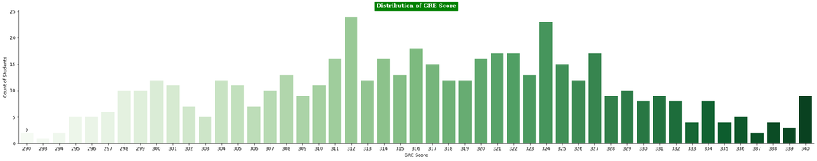

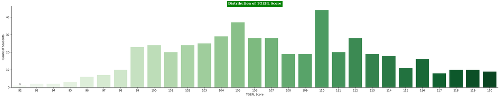

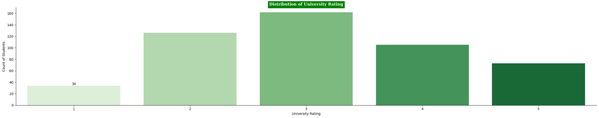

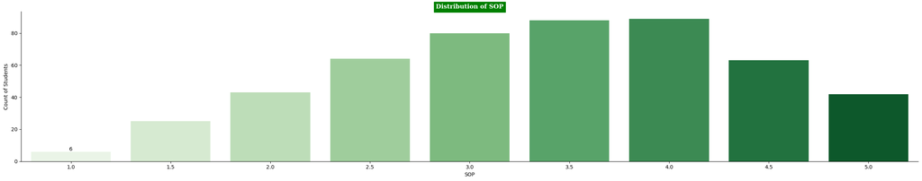

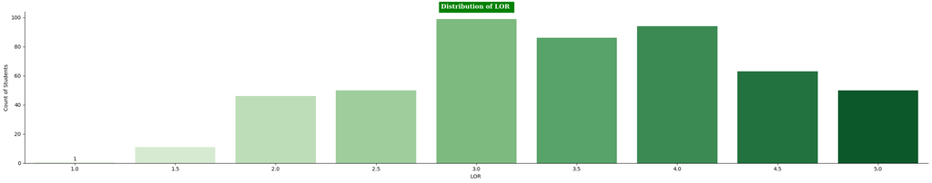

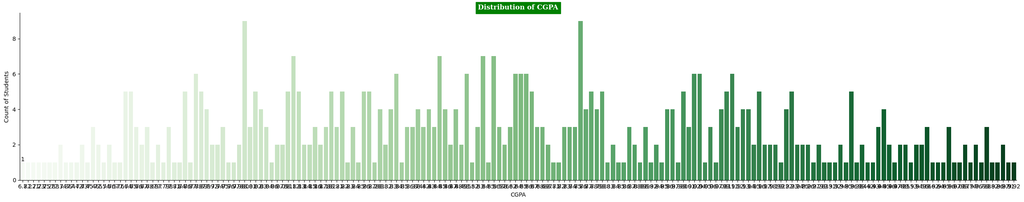

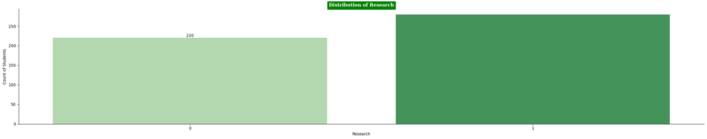

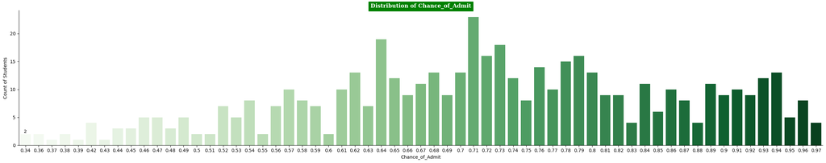

```python
for col in df.columns:
    plt.figure(figsize=(25,5))
    plt.style.use('default')
    plt.style.use('fast')
    b = sns.countplot(x=df[col],palette=cp)
    plt.title(f'Distribution of {col}',fontsize=12,fontfamily='serif',fontweight='bold',backgroundcolor='g',color='w')
    b.bar_label(b.containers[0], label_type='edge',fmt='%d')
    plt.xlabel(col)
    plt.ylabel('Count of Students')
    plt.tight_layout()
    sns.despine()
    plt.show();
```

```python
df.columns
```

```
Index(['GRE Score', 'TOEFL Score', 'University Rating', 'SOP', 'LOR ', 'CGPA',
       'Research', 'Chance_of_Admit'],
      dtype='object')
```

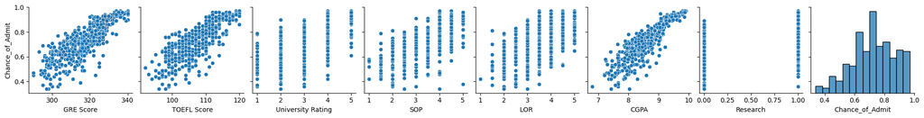

```python
sns.pairplot(data=df, y_vars='Chance_of_Admit')
plt.show()
```

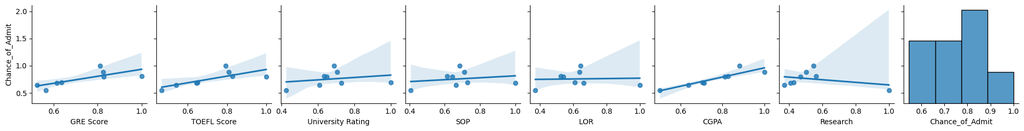

```python
sns.pairplot(df.corr(),y_vars='Chance_of_Admit',kind= 'reg')
```

```python
df.columns
```

```
Index(['GRE Score', 'TOEFL Score', 'University Rating', 'SOP', 'LOR ', 'CGPA',
       'Research', 'Chance_of_Admit'],
      dtype='object')
```

```
GRE Score
```

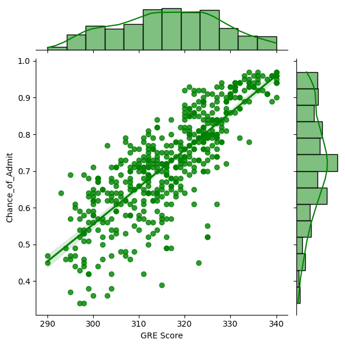

```
TOEFL Score
```

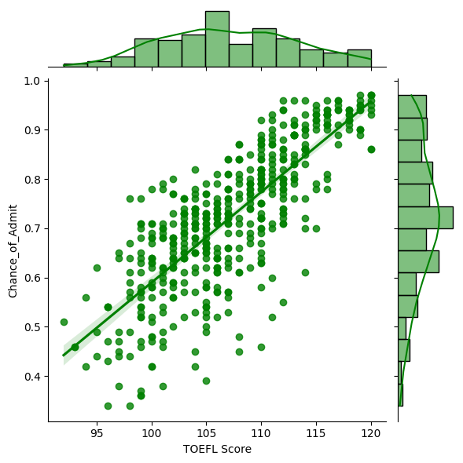

```
University Rating
```

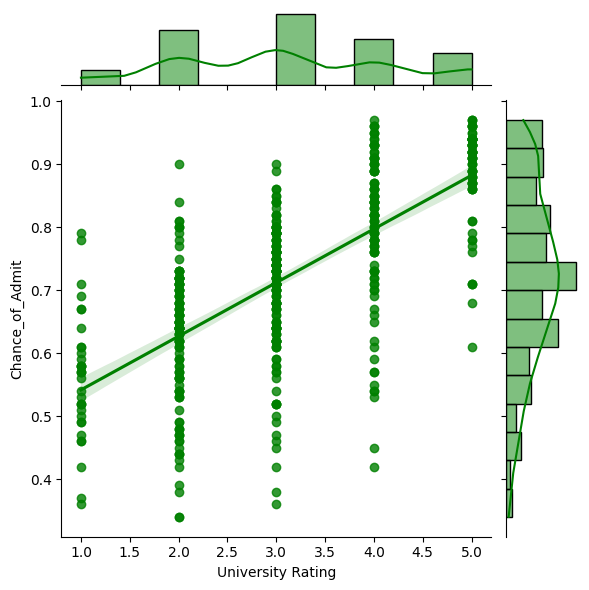

```
SOP
```

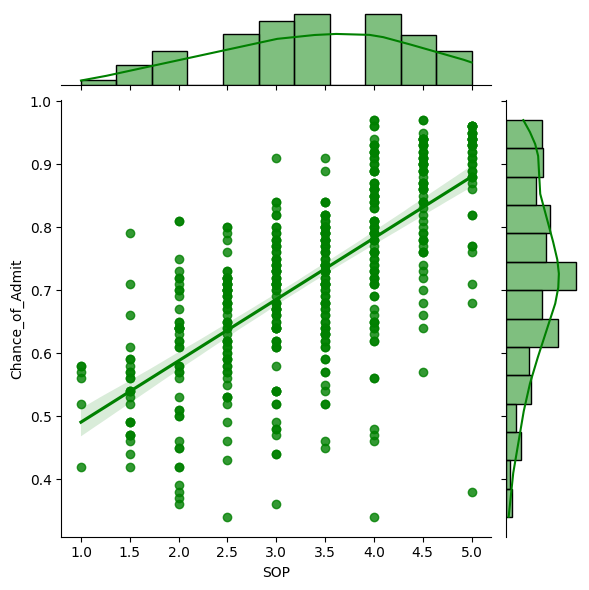

```
LOR
```

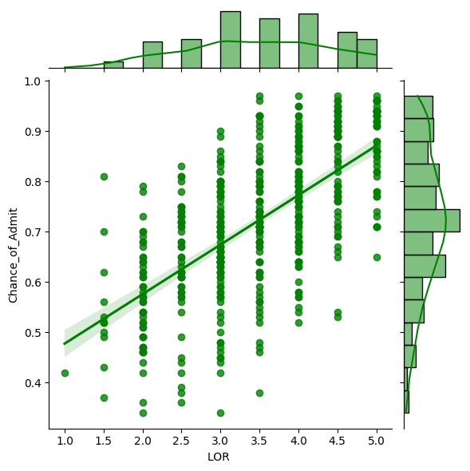

```
CGPA
```

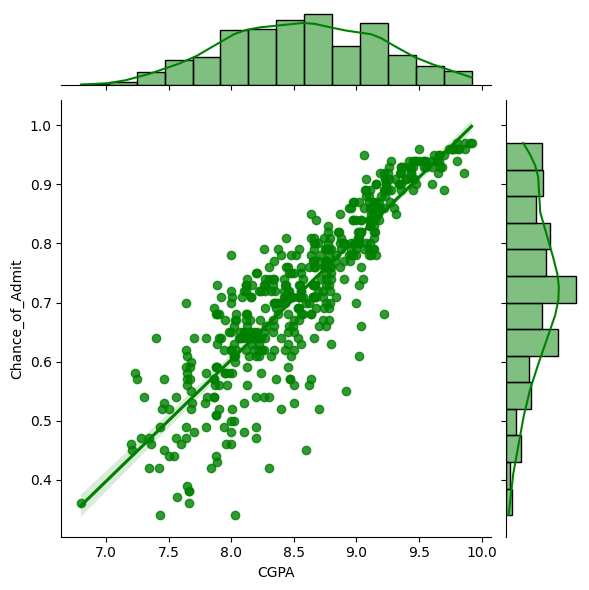

```
Research
```

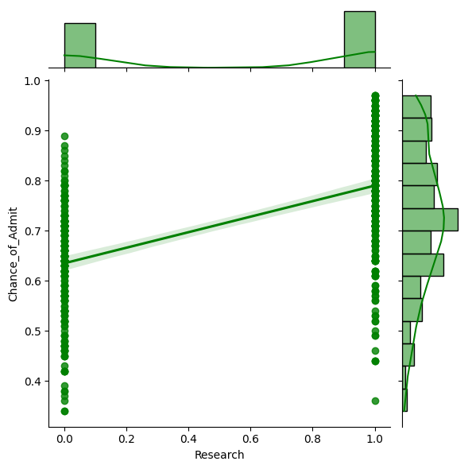

```python
for col in df.columns[:-1]:
    print(col)
    sns.jointplot(data=df,x=df[col],y=df["Chance_of_Admit"],kind="reg",color='g')
    plt.show()
```